# Análise exploratória: desvínculo e trancamento

Datanautas — Datathon Impacta.dev 2026

Autor

Equipe Datanautas

Data de Publicação

23 de outubro de 2026

## Sobre este notebook

Este notebook parte **apenas do arquivo original** `data/raw/cursos_ano.parquet` e refaz toda a análise exploratória do projeto. Ele estende a EDA original da equipe (caderno `02_EDA.ipynb` do branch exploratório `sanches`, já não mantido no `dev`), que usava só o desvínculo, mostrando lado a lado três medidas:

| Medida | Fórmula | Uso |
| --- | --- | --- |
| **Desvínculo** | desvinculados ÷ vínculos | medida da EDA original |
| **Trancamento** | trancados ÷ vínculos | componente separado |
| **Desvínculo + trancamento** | (desvinculados + trancados) ÷ vínculos | **resposta do modelo** (notebook 02) |

Os vínculos somam matriculados (cursando ou formados), trancados, desvinculados, transferidos e falecidos.

Para renderizar, a partir da raiz do repositório:

```bash
nix develop -c quarto render notebooks/01_EDA_trancamento.qmd
```

Todas as comparações deste notebook são **associações descritivas, sem controles**. O notebook 02 verifica quais delas se sustentam quando se comparam cursos parecidos da mesma instituição.

**Mostrar código**

```r
suppressPackageStartupMessages({library(data.table); library(ggplot2); library(knitr)})
setDTthreads(2)
br  <- function(x, d = 1) formatC(x, format = "f", digits = d, big.mark = ".", decimal.mark = ",")
pct <- function(x, d = 1) paste0(br(100 * x, d), "%")
tab <- function(x, ...) kable(x, format.args = list(big.mark = ".", decimal.mark = ","), ...)
MED   <- c(desvinculo = "Desvínculo", trancamento = "Trancamento", composta = "Desvínculo + trancamento")
CORES <- c("Desvínculo" = "#eb6834", "Trancamento" = "#6250d6", "Desvínculo + trancamento" = "#2a78d6")
theme_set(theme_minimal(base_size = 12) +
  theme(legend.position = "bottom", plot.title.position = "plot", panel.grid.minor = element_blank()))
rotulo_pct <- scales::label_percent(accuracy = 1)
# Taxas agregadas: soma dos numeradores ÷ soma dos vínculos (nunca média simples de taxas).
taxas <- function(g) g[, .(vinculos = sum(vinculos),
  desvinculo = sum(desvinculados) / sum(vinculos), trancamento = sum(trancados) / sum(vinculos),
  composta = sum(desvinculados + trancados) / sum(vinculos))]
longo <- function(x, ids) melt(x, id.vars = ids, measure.vars = names(MED), variable.name = "medida",
  value.name = "taxa")[, medida := factor(MED[as.character(medida)], levels = MED)]
```

# 1 Dados e população

**Mostrar código**

```r
bruto <- as.data.table(nanoparquet::read_parquet("data/raw/cursos_ano.parquet"))
num <- c("desvinculados", "trancados", "transferidos", "falecidos", "vinculos", "matriculas",
         "mat_noturno", "mat_escola_publica", "mat_prouni", "ingressantes")
for (v in num) set(bruto, j = v, value = as.numeric(bruto[[v]]))
stopifnot(all(bruto$vinculos == bruto$matriculas + bruto$trancados + bruto$desvinculados +
                bruto$transferidos + bruto$falecidos))
d <- bruto[presente_5_anos == 1 & poucos_alunos == 0 & matriculas > 0]
d[, `:=`(prop_noturno = mat_noturno / matriculas, prop_escola_publica = mat_escola_publica / matriculas,
         prop_prouni = mat_prouni / matriculas)]
tab(data.table(
  Etapa = c("Base original (curso-anos)", "Cursos presentes nos 5 anos e ≥ 30 vínculos", "… e com matrículas positivas"),
  `Curso-anos` = c(nrow(bruto), bruto[presente_5_anos == 1 & poucos_alunos == 0, .N], nrow(d)),
  Cursos = c(uniqueN(bruto$co_curso), bruto[presente_5_anos == 1 & poucos_alunos == 0, uniqueN(co_curso)], uniqueN(d$co_curso))))
```

| Etapa | Curso-anos | Cursos |
| --- | --- | --- |
| Base original (curso-anos) | 220.686 | 53.147 |
| Cursos presentes nos 5 anos e ≥ 30 vínculos | 152.943 | 32.973 |
| … e com matrículas positivas | 152.484 | 32.953 |

A identidade contábil dos vínculos foi conferida em todas as linhas. A população tem três filtros:

- **presente nos cinco anos:** compara-se a mesma oferta de cursos ao longo do tempo;
- **pelo menos 30 vínculos no ano:** taxas de cursos minúsculos são instáveis;
- **matrículas positivas:** é a condição do modelo do notebook 02. A EDA original não a exigia, e por isso tinha 459 linhas a mais.

O preço é que os resultados valem para cursos estáveis e não muito pequenos.

# 2 Distribuição da variável resposta

**Mostrar código**

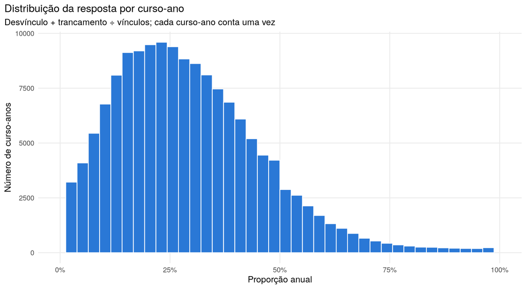

```r
d[, taxa_resposta := (desvinculados + trancados) / vinculos]
ggplot(d, aes(taxa_resposta)) +
  geom_histogram(bins = 40, fill = "#2a78d6", colour = "white") +
  scale_x_continuous(labels = rotulo_pct, limits = c(0, 1)) +
  labs(title = "Distribuição da resposta por curso-ano",
       subtitle = "Desvínculo + trancamento ÷ vínculos; cada curso-ano conta uma vez",
       x = "Proporção anual", y = "Número de curso-anos")
```

# 3 Taxas por rede e modalidade

**Mostrar código**

```r
rm_ <- d[, taxas(.SD), by = .(rede, modalidade)][order(rede, modalidade)]
tab(rm_[, .(Rede = rede, Modalidade = modalidade, Vínculos = vinculos, Desvínculo = pct(desvinculo),
            Trancamento = pct(trancamento), `Desvínculo + trancamento` = pct(composta))],
    caption = "2020–2024 agregado", align = "llrrrr")
```

2020–2024 agregado

| Rede | Modalidade | Vínculos | Desvínculo | Trancamento | Desvínculo + trancamento |
| --- | --- | --- | --- | --- | --- |
| Privada | EAD | 29.740.882 | 25,2% | 13,7% | 39,0% |
| Privada | Presencial | 22.235.493 | 16,8% | 12,0% | 28,8% |
| Pública | EAD | 1.180.676 | 13,7% | 19,3% | 32,9% |
| Pública | Presencial | 11.689.807 | 10,8% | 10,9% | 21,8% |

**Mostrar código**

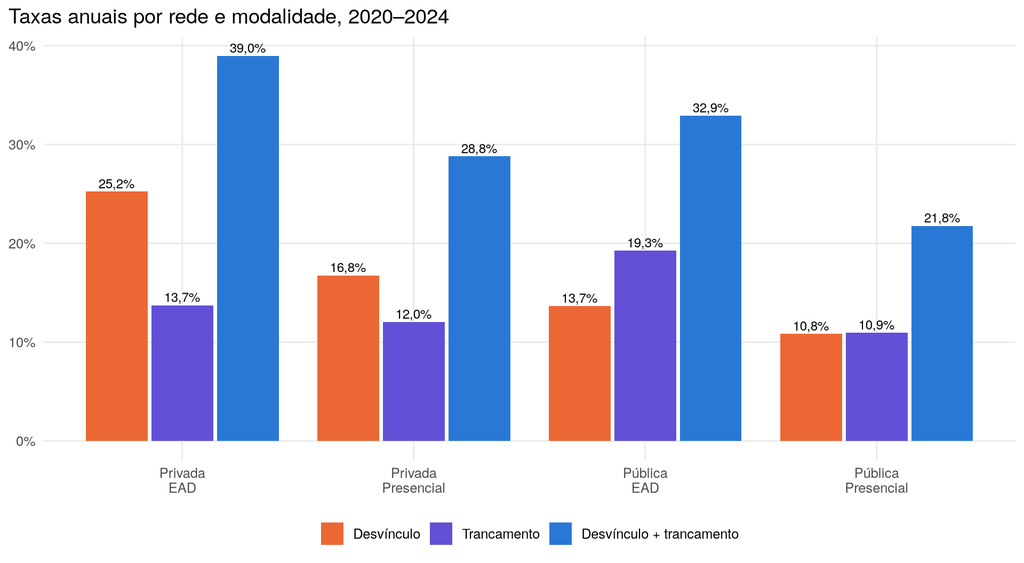

```r
ggplot(longo(rm_, c("rede", "modalidade", "vinculos")), aes(paste(rede, modalidade, sep = "\n"), taxa, fill = medida)) +
  geom_col(position = position_dodge(.85), width = .8) +
  geom_text(aes(label = pct(taxa)), position = position_dodge(.85), vjust = -.35, size = 3.2) +
  scale_fill_manual(values = CORES, name = NULL) + scale_y_continuous(labels = rotulo_pct) +
  labs(title = "Taxas anuais por rede e modalidade, 2020–2024", x = NULL, y = NULL)
```

O trancamento muda bastante a leitura. No **EAD público**, a taxa composta é mais que o dobro da de desvínculo (33% contra 14%). Olhar só o desvínculo esconderia boa parte da interrupção nesse grupo.

# 4 Evolução 2020–2024

**Mostrar código**

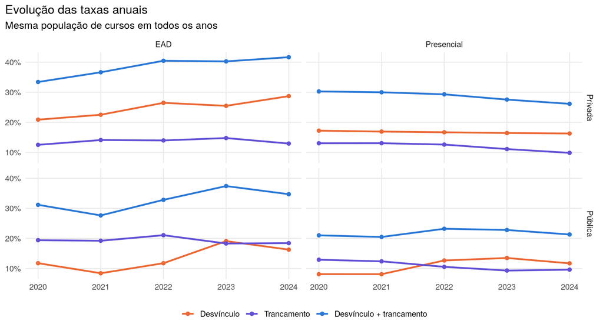

```r
ev <- d[, taxas(.SD), by = .(ano, rede, modalidade)]
ggplot(longo(ev, c("ano", "rede", "modalidade", "vinculos")), aes(ano, taxa, colour = medida)) +
  geom_line(linewidth = 1) + geom_point(size = 1.8) + facet_grid(rede ~ modalidade) +
  scale_colour_manual(values = CORES, name = NULL) + scale_y_continuous(labels = rotulo_pct) +
  labs(title = "Evolução das taxas anuais", subtitle = "Mesma população de cursos em todos os anos", x = NULL, y = NULL)
```

**Mostrar código**

```r
mod <- dcast(d[, .(t = sum(desvinculados + trancados) / sum(vinculos)), by = .(modalidade, ano)], modalidade ~ ano, value.var = "t")
mod[, (2:6) := lapply(.SD, pct), .SDcols = 2:6]
tab(mod, caption = "Desvínculo + trancamento por modalidade")
```

Desvínculo + trancamento por modalidade

| modalidade | 2020 | 2021 | 2022 | 2023 | 2024 |
| --- | --- | --- | --- | --- | --- |
| EAD | 33,3% | 36,3% | 40,2% | 40,2% | 41,4% |
| Presencial | 27,4% | 26,8% | 27,1% | 25,8% | 24,4% |

# 5 Turno noturno dentro da mesma instituição

Cursos noturnos concentram estudantes que trabalham. Para não confundir o turno com o tipo de instituição, comparamos **dentro de cada IES** os cursos predominantemente noturnos (≥ 70% dos matriculados à noite) com os predominantemente diurnos (≤ 30%), no presencial de 2024. Em cada IES, cada grupo tem sua taxa agregada, e calculamos a diferença noturno − diurno.

**Mostrar código**

```r
p24 <- d[ano == 2024 & modalidade == "Presencial"]
p24[, turno := fifelse(prop_noturno >= .7, "Noturno", fifelse(prop_noturno <= .3, "Diurno", NA_character_))]
pr <- p24[!is.na(turno), taxas(.SD), by = .(rede, co_ies, turno)]
pw <- dcast(pr, rede + co_ies ~ turno, value.var = names(MED))[!is.na(desvinculo_Noturno) & !is.na(desvinculo_Diurno)]
for (m in names(MED)) pw[, (paste0("dif_", m)) := 100 * (get(paste0(m, "_Noturno")) - get(paste0(m, "_Diurno")))]
par_ <- melt(pw, id.vars = c("rede", "co_ies"), measure.vars = paste0("dif_", names(MED)),
             variable.name = "medida", value.name = "dif_pp")[, medida := factor(MED[sub("^dif_", "", medida)], levels = MED)]
resumo_nt <- rbind(par_[, .(rede = "Total", IES = .N, mediana = median(dif_pp), positiva = mean(dif_pp > 0)), by = medida],
                   par_[, .(IES = .N, mediana = median(dif_pp), positiva = mean(dif_pp > 0)), by = .(medida, rede)], use.names = TRUE)
tab(resumo_nt[, .(Medida = medida, Rede = rede, IES, `Mediana noturno − diurno (pp)` = br(mediana),
                  `IES com diferença > 0` = pct(positiva, 0))], align = "llrrr")
```

| Medida | Rede | IES | Mediana noturno − diurno (pp) | IES com diferença > 0 |
| --- | --- | --- | --- | --- |
| Desvínculo | Total | 589 | 4,1 | 78% |
| Trancamento | Total | 589 | 0,9 | 68% |
| Desvínculo + trancamento | Total | 589 | 5,5 | 79% |
| Desvínculo | Privada | 389 | 4,7 | 81% |
| Desvínculo | Pública | 200 | 2,8 | 73% |
| Trancamento | Privada | 389 | 1,0 | 68% |
| Trancamento | Pública | 200 | 0,7 | 67% |
| Desvínculo + trancamento | Privada | 389 | 6,7 | 82% |
| Desvínculo + trancamento | Pública | 200 | 4,4 | 74% |

**Mostrar código**

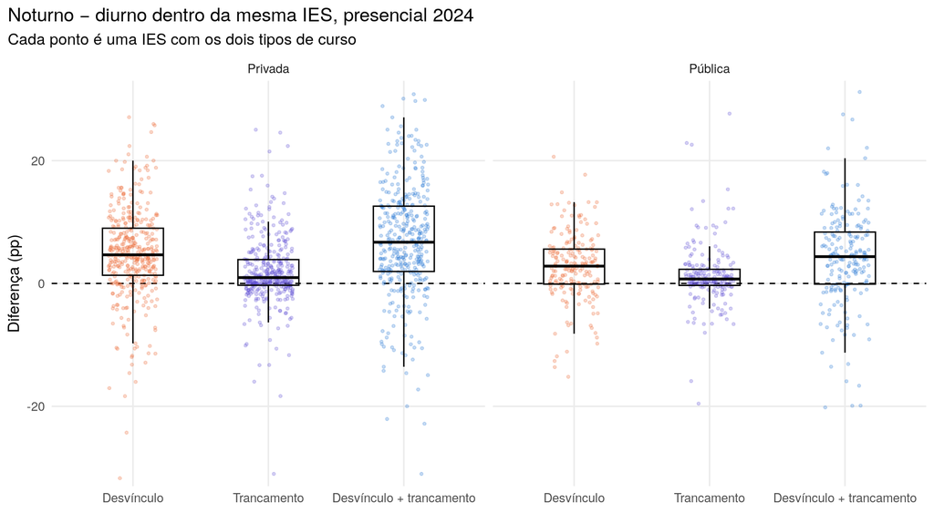

```r
set.seed(2026)
ggplot(par_, aes(medida, dif_pp, colour = medida)) + geom_hline(yintercept = 0, linetype = 2) +
  geom_jitter(width = .18, alpha = .25, size = .8) + geom_boxplot(fill = NA, colour = "black", outlier.shape = NA, width = .45) +
  facet_wrap(~rede) + scale_colour_manual(values = CORES, guide = "none") + coord_cartesian(ylim = c(-30, 30)) +
  labs(title = "Noturno − diurno dentro da mesma IES, presencial 2024", subtitle = "Cada ponto é uma IES com os dois tipos de curso",
       x = NULL, y = "Diferença (pp)")
```

**Mostrar código**

```r
nt_tot <- resumo_nt[medida == "Desvínculo + trancamento" & rede == "Total"]
```

Em 589 instituições com os dois tipos de curso, os noturnos têm taxa composta mediana **5,5 pp maior**, e a diferença é positiva em 79% delas. A diferença é maior na medida composta do que no desvínculo isolado: cursos noturnos também trancam mais. É o achado exploratório mais robusto. No notebook 02, o modelo estima quanto dessa diferença persiste depois de controlar idade, origem escolar, área e porte.

# 6 Egressos de escola pública

**Mostrar código**

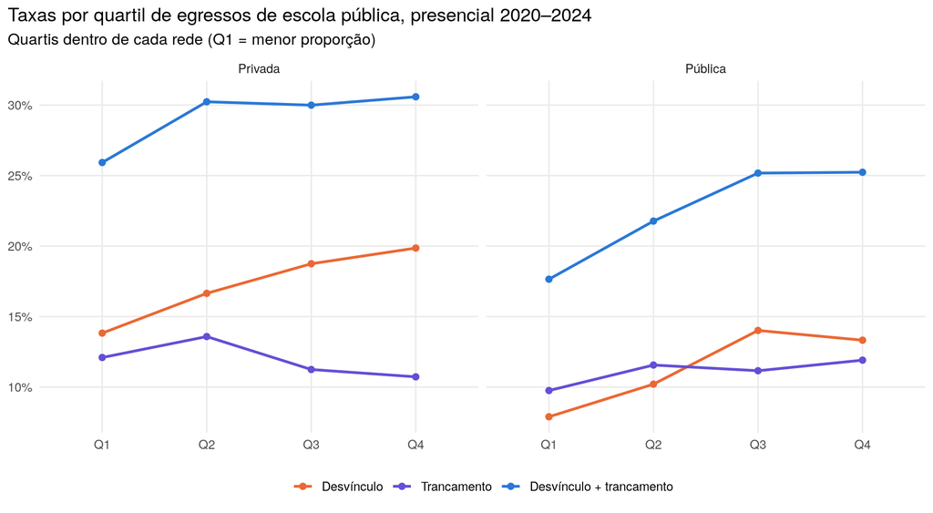

```r
pp <- d[modalidade == "Presencial"]
pp[, quartil := cut(prop_escola_publica, unique(quantile(prop_escola_publica, 0:4 / 4)), include.lowest = TRUE, labels = FALSE), by = rede]
ep <- pp[, c(taxas(.SD), list(prop_media = mean(prop_escola_publica))), by = .(rede, quartil)][order(rede, quartil)]
ggplot(longo(ep, c("rede", "quartil", "vinculos", "prop_media")), aes(factor(paste0("Q", quartil)), taxa, colour = medida, group = medida)) +
  geom_line(linewidth = 1) + geom_point(size = 2) + facet_wrap(~rede) +
  scale_colour_manual(values = CORES, name = NULL) + scale_y_continuous(labels = rotulo_pct) +
  labs(title = "Taxas por quartil de egressos de escola pública, presencial 2020–2024",
       subtitle = "Quartis dentro de cada rede (Q1 = menor proporção)", x = NULL, y = NULL)
```

O desvínculo cresce do 1º para o 4º quartil nas duas redes. Na medida composta, a rede privada sobe do 1º para o 2º quartil e depois estabiliza. A relação existe, mas é mais fraca do que parece olhando só o desvínculo.

# 7 ProUni na rede privada

**Mostrar código**

```r
pv <- p24[rede == "Privada" & nome_cine_area_geral != "Programas básicos"]
pv[, quartil := cut(rank(prop_prouni, ties.method = "first"), 4, labels = FALSE)]
pu <- pv[, c(taxas(.SD), list(cursos = .N, cobertura = mean(prop_prouni))), by = quartil][order(quartil)]
tab(pu[, .(Quartil = paste0("Q", quartil), Cursos = cursos, `Cobertura média` = pct(cobertura),
           Desvínculo = pct(desvinculo), Trancamento = pct(trancamento), `Desvínculo + trancamento` = pct(composta))],
    caption = "Privada presencial, 2024", align = "lrrrrr")
```

Privada presencial, 2024

| Quartil | Cursos | Cobertura média | Desvínculo | Trancamento | Desvínculo + trancamento |
| --- | --- | --- | --- | --- | --- |
| Q1 | 3.737 | 0,1% | 14,4% | 11,4% | 25,8% |
| Q2 | 3.737 | 5,7% | 16,1% | 9,1% | 25,2% |
| Q3 | 3.737 | 11,7% | 16,7% | 9,9% | 26,5% |
| Q4 | 3.737 | 24,7% | 17,9% | 9,4% | 27,4% |

**Atenção.** No desvínculo isolado, cursos com mais bolsistas parecem perder mais alunos (14,4% → 17,9%). Na medida composta, a relação quase some (25,8% → 27,4%), porque esses cursos trancam menos. O ProUni parece mudar a forma da saída, não o seu volume. Isto não sustenta a afirmação de que o ProUni aumenta a desistência. O FIES não é analisado: há zeros intermitentes em grandes instituições que parecem falta de registro.

# 8 Área do conhecimento (Cine)

**Mostrar código**

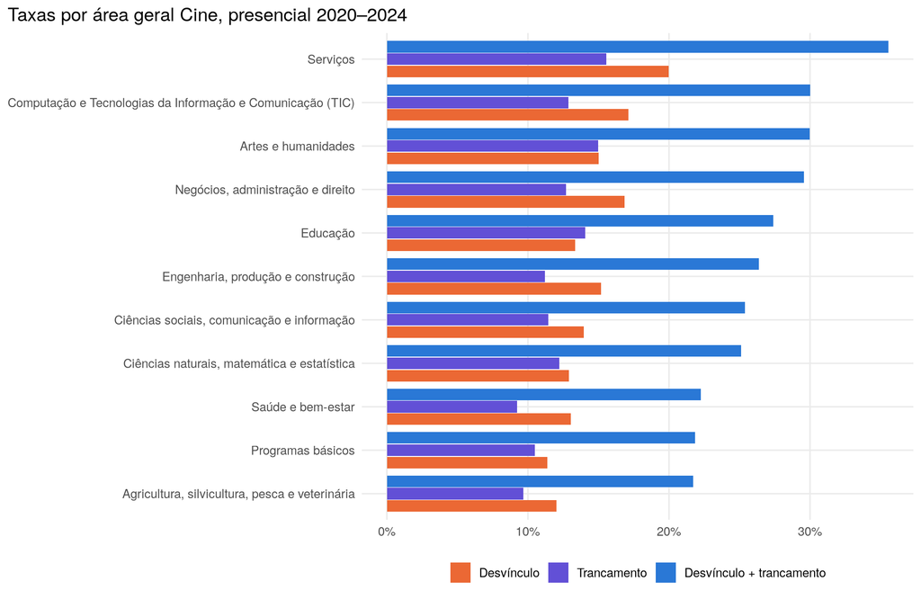

```r
ci <- pp[, taxas(.SD), by = nome_cine_area_geral][order(composta)]
ggplot(longo(ci, c("nome_cine_area_geral", "vinculos")), aes(taxa, factor(nome_cine_area_geral, levels = ci$nome_cine_area_geral), fill = medida)) +
  geom_col(position = position_dodge(.85), width = .8) + scale_fill_manual(values = CORES, name = NULL) +
  scale_x_continuous(labels = rotulo_pct) + labs(title = "Taxas por área geral Cine, presencial 2020–2024", x = NULL, y = NULL)
```

Na medida composta, Agricultura (21,7%), Programas básicos e Saúde e bem-estar (22,3%) têm as menores taxas; Serviços (35,5%), TIC, Artes e Negócios (≈ 30%), as maiores. Áreas diferem em perfil de aluno e de instituição; o notebook 02 mostra que parte da ordem bruta muda com os controles.

# 9 Síntese

1. O **EAD** concentra a alta da interrupção: de 33% para 41% entre 2020 e 2024.
2. **Cursos noturnos** têm taxas maiores do que os diurnos da mesma instituição, e a diferença aumenta quando se inclui o trancamento.
3. **Escola pública** se associa a taxas maiores, de forma mais fraca na medida composta.
4. **ProUni**: o gradiente do desvínculo desaparece quando se soma o trancamento.

Todas são associações sem controles. O notebook `02_modelo_inferencial.qmd` testa quais delas se mantêm comparando cursos semelhantes da mesma instituição.